# EDS 223: Discussion Week 1 - Making Maps

Allie Caughmam

2023-08-28

## introduction

The following exercises are modified from [Chapter 9 of Geocomputation with R by Rovin Lovelace](https://geocompr.robinlovelace.net/adv-map.html).

## prerequisites

```r
library(sf)
library(raster)
library(terra)
library(spData)
library(spDataLarge)
library(tidyverse)
library(ggspatial)
library(patchwork)
```

## Exercise 1

These exercises rely on a new data object based on the **world** and **worldbank_df** datasets from the **spData* package.

```r
africa = world |>
  filter(continent == "Africa", !is.na(iso_a2)) |>
  left_join(worldbank_df, by = "iso_a2") |>
  dplyr::select(name, subregion, gdpPercap, HDI, pop_growth) |>
  st_transform("+proj=aea +lat_1=20 +lat_2=-23 +lat_0=0 +lon_0=25")
```

## Map 1

Create a map showing the geographic distribution of the Human Development Index (HDI) across Africa.

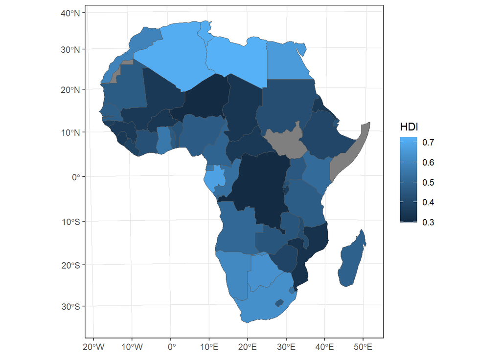

```r
m1 = ggplot(africa) +
  # geom_sf(aes(color) = HDI)) +
  geom_sf(aes(fill = HDI)) +
  theme_bw()
m1
```

## Map 2

Update the map created for question 1 so the legend has three bins: “high” (HDI above 0.7), “medium” (HDI between 0.55 and 0.7), and “low” (HDI below 0.55).

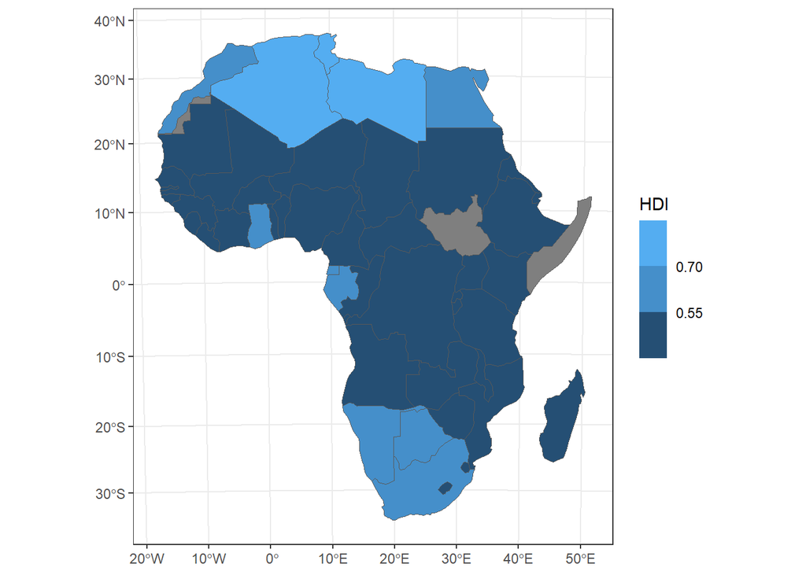

```r
m2 = m1 +
  scale_fill_binned(breaks = c(.55, 0.7))
m2
```

## Map 3

Represent Africa’s subregions on the map.  
- change the color palette - change the legend title

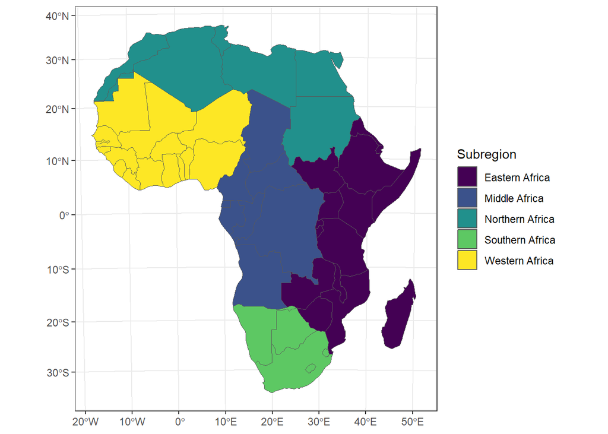

```r
m3 = ggplot(africa) +
  geom_sf(aes(fill = subregion)) +
  theme_bw() +
  scale_fill_viridis_d() +
  labs(fill = "Subregion")
m3
```

- combine this map with the map from question 2 into a single plot

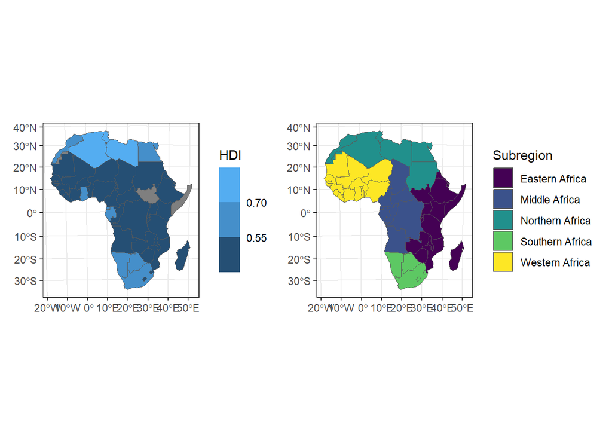

```r
m2 + m3
```

## Exercise 2

Here, we will use the **zion** and **nlcd** datasets from the **spDataLarge** package.

```r
zion = st_read((system.file("vector/zion.gpkg", package = "spDataLarge")))
# For spDataLarge version 2.0.X
# data(nlcd, package = "spDataLarge")
# force(nlcd)

# For spDataLarge version 2.1.1
nlcd = rast(system.file("raster/nlcd.tif", package = "spDataLarge"))
```

First, we need to convert the raster into a dataframe

```r
nlcd_df = as.data.frame(nlcd, xy=TRUE)
```

## Map 4

Create a land cover map of Zion National Park  
- change the default colors to match your perception of land cover categories  
- move the map legend outside of the map to improve readability - add a scale bar and north arrow and change the position of both to improve the maps aesthetics - add the park boundaries on top of the land cover map

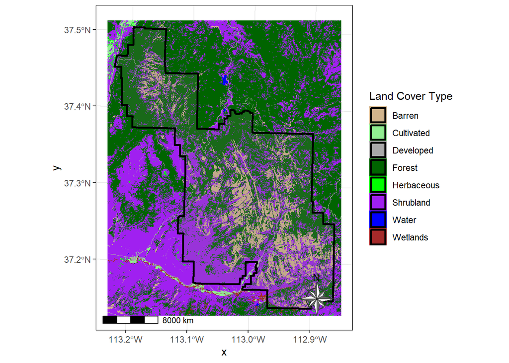

```r
m4 = ggplot() +
  geom_raster(data = nlcd_df, aes(x=x, y=y, fill = levels)) + #layer_levels is using spDataLarge 2.0.9
  geom_sf(data = zion, aes(fill = NA), alpha = 0.2, linewidth = 1, color = "black") +
  labs(fill = "Land Cover Type") +
  theme_bw() +
  scale_fill_manual(values = c("tan", "lightgreen", "darkgrey", "darkgreen", "green", "purple", "blue", "brown")) +
  annotation_scale(plot_unit = "km") +
  annotation_north_arrow(location = "br",
                         pad_x = unit(0.2, "in"),
                         pad_y = unit(0.2, "in"),
                         style = ggspatial::north_arrow_nautical(fill = c("grey40", "white"),
                                                                 line_col = "grey20"))
m4
```

## Map 5

- add an inset of Zion’s location in the context of the state of Utah
  - hint: an object representing Utah can be subset from the **us_states** dataset)

```r
states = us_states %>%
  janitor::clean_names() %>%
  filter(name == "Utah")
```

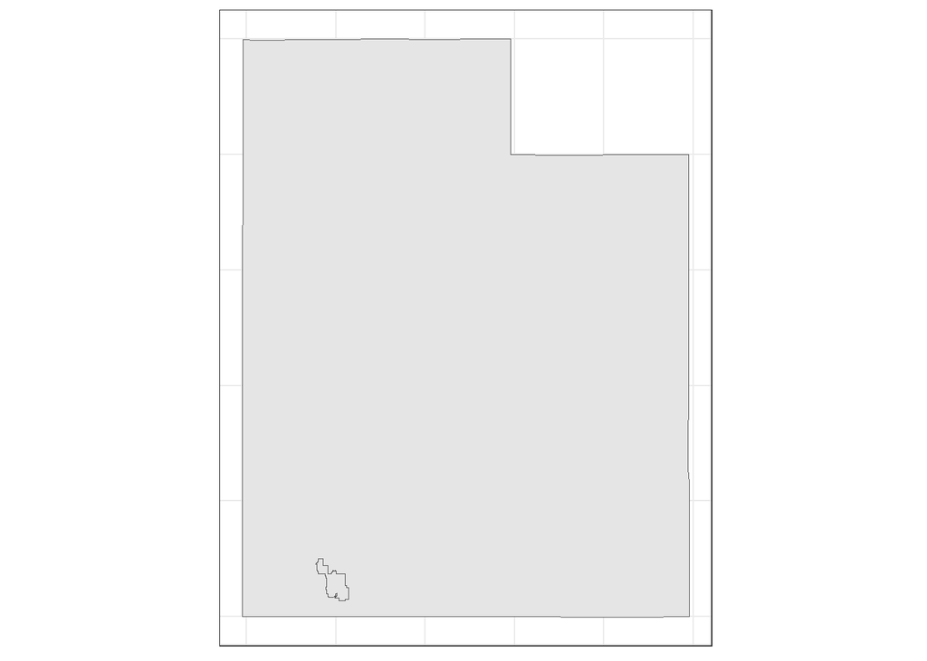

```r
m5 = ggplot() +
  geom_sf(data = states) +
  geom_sf(data = zion) +
  theme_bw() +
  theme(axis.text = element_blank(),
        axis.ticks = element_blank())
m5
```

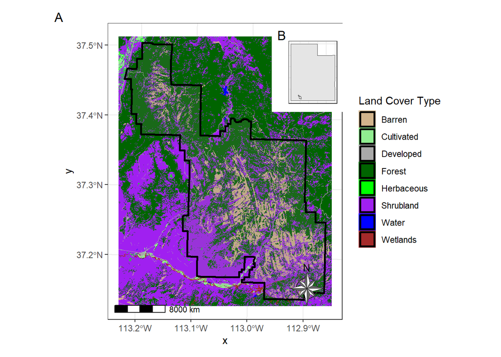

```r
m4 + inset_element(m5, 0.7, 0.7, 1, 1) + plot_annotation(tag_levels = "A")
```